[O’Hara on GitHub](https://github.com/oharac)

# Map SST rise impacts

Compiled on Sat Apr 9 16:16:28 2022 by ohara

```r
knitr::opts_chunk$set(echo = TRUE, message = FALSE, warning = FALSE, fig.height = 4, fig.width = 7)

library(raster)
library(oharac)
library(tidyverse)
library(here)
source(here('common_fxns.R'))
```

# 1 Summary

Because thermal sensitivity to SST rise is based on thermal tolerance of spp, exposure is not identical across all spp in a cell. The SST rise stressor script (`_setup/stressors/6b_thermal_stressor_calc.Rmd`) generates a stressor map for each species. The current script reads in the stressor map for each species, multiplies by the spp vulnerability (primarily driven by adaptive capacity) to calculate impact. These spp-level impacts are then aggregated by:

- unweighted mean impact in each cell across all spp present
- unweighted mean impact in each cell across only spp included in functional vulnerability calculations (for better comparison against FV weighting)
- functional-vulnerability-weighted mean impact in each cell.

# 2 Data

- Vulnerability data from Ecosphere trait-based vulnerability
- Stressor data from the script noted above - based on AquaMaps thermal tolerances and mean SST maps

# 3 Methods

## 3.1 Set up spp map source and vulnerability data

Filter to just SST rise stressor.

```r
spp_am <- get_am_spp_info()  %>%
  filter(occur_cells >= 10) %>%
  select(species = sciname) %>%
  mutate(am_mapped = TRUE) %>%
  distinct()

spp_iucn <- read_csv(here('_data/iucn_spp/iucn_to_worms_match.csv'), show_col_types = FALSE) %>%
  rename(species = worms_name, iucn_mapped = mapped)

spp_worms <- assemble_worms() %>%
  select(species) %>%
  mutate(worms = TRUE) %>%
  distinct()

spp_vuln <- get_spp_vuln() %>%
  filter(stressor == 'sst_rise') %>%
  select(species, score, taxon) %>%
  mutate(in_vuln = TRUE) %>%
  distinct()

all_spp <- spp_worms %>%
  full_join(spp_vuln, by = 'species') %>%
  full_join(spp_am,   by = 'species') %>%
  full_join(spp_iucn, by = 'species')

spp_for_vuln_calc <- all_spp %>%
  filter(!is.na(score)) %>%
  ### mapped in AquaMaps and/or IUCN
  filter(am_mapped | iucn_mapped)
```

```r
### These are created in _setup/stressors/6b_thermal_stressor_calc.Rmd
sst_map_stem <- here_anx('stressors/max_temp/%s_spp_max_temp_%s.csv')

mapfile_df <- spp_for_vuln_calc %>%
  select(species, am_mapped, iucn_mapped, iucn_sid) %>%
  distinct() %>%
  mutate(src = ifelse(iucn_mapped & !is.na(iucn_mapped), 'iucn', 'am'),
         id  = ifelse(src == 'iucn', iucn_sid, str_replace_all(species, ' ', '_')),
         map_f = sprintf(sst_map_stem, src, id)) %>%
  select(species, src, map_f) %>%
  distinct()

check_tryerror <- function(l) {
  x <- sapply(l, class) %>%
    unlist()
  return(any(x == 'try-error'))
}
```

## 3.2 Impacts by unweighted mean vulnerability, all species

### 3.2.1 Calculate mean thermal impacts per taxon

Loop over each taxon; pull all max temp stressor files for that taxon. For each species in the taxon, multiply thermal stressor map by the spp vulnerability to identify impact map for that species. Summarize across the entire taxon to mean, sd, and nspp.

```r
taxa <- spp_for_vuln_calc$taxon %>% unique() %>% sort()

out_stem <- here_anx('impact_maps_by_taxon/impacts_tx_sst_rise',
                     'imp_unweighted_sst_rise_all',
                     'imp_unweighted_sst_rise_%s_%s.tif')
### zxcv <- list.files(dirname(out_stem), full.names = TRUE)
### unlink(zxcv)
for(t in taxa) {
  ### t <- taxa[10]
  tx_vuln_df <- spp_for_vuln_calc %>%
    filter(taxon == t) %>%
    select(species, score) %>%
    distinct()

  outf_mean <- sprintf(out_stem, t, 'mean')
  outf_sdev <- sprintf(out_stem, t, 'sdev')
  outf_nspp <- sprintf(out_stem, t, 'nspp')
  if(all(file.exists(outf_mean, outf_sdev, outf_nspp))) {
    message('Rasters exist for taxon ', t, ' for sst rise stressor... skipping!')
    next()
  }
  ### read in all sst thermal stressor maps for this taxon -
  tx_mapfiles <- mapfile_df %>%
    filter(species %in% tx_vuln_df$species) %>%
    distinct()

  message('Loading thermal stress maps for taxon ', t, '...')
  tx_maps_list <- parallel::mclapply(
                    tx_mapfiles$map_f,
                    mc.cores = 40,
                    FUN = function(f) {
                      if(file.exists(f)) {
                        df <- data.table::fread(f)
                        return(df)
                      } else {
                        return(data.frame(cell_id = -1,
                                          therm_prs = NA))
                      }
                    })
  if(check_tryerror(tx_maps_list)) {
    message('Something went wrong with loading maps for taxon ', t, '... skipping for now!')
    next()
  }
  message('Binding thermal stress maps for taxon ', t, '...')
  tx_maps <- tx_maps_list %>%
    setNames(tx_mapfiles$species) %>%
    data.table::rbindlist(idcol = 'species')

  message('Taxon ', t, ' thermal stressor dataframe: ', nrow(tx_maps),
          ' cell observations for ', nrow(tx_mapfiles), ' species...')
  if(any(tx_maps$cell_id == -1)) {
    n_na <- tx_maps %>%
      filter(cell_id == -1)
    message('NOTE: ', nrow(n_na), ' instances of missing thermal pressure maps detected!')
  }

  message('Processing mean/sd vulnerability by species in taxon ', t, ' to thermal stressor...')

  ### because failures might occur with summarizing a huge dataset,
  ### let's break this into chunks by cell_id - there are 6.6e+06 cells total
  chunk_size <- 500000
  n_chunks <- ceiling(ncell(raster::raster(here('_spatial/ocean_area_mol.tif'))) / chunk_size)
  n_cores <- max(1, floor(n_chunks / ceiling(nrow(tx_maps)/3e7)))
  # system.time({
  result_list <- parallel::mclapply(1:n_chunks, mc.cores = n_cores,
                 FUN = function(n) { ### n <- 3
                   cell_id_min <- as.integer((n - 1) * chunk_size + 1)
                   cell_id_max <- as.integer(n * chunk_size)
                   message('Summarizing thermal stressor on taxon ', t,
                           ': cells ', cell_id_min, ' - ', cell_id_max, '...')

                   chunk_sum <- tx_maps %>%
                     filter(between(cell_id, cell_id_min, cell_id_max)) %>%
                     oharac::dt_join(tx_vuln_df, by = 'species', type = 'inner') %>%
                     mutate(impact = score * therm_prs) %>%
                     group_by(cell_id) %>%
                     summarize(impact_mean = mean(impact) %>% round(5),
                               impact_sd   = sd(impact) %>% round(5),
                               n_spp       = n_distinct(species),
                               .groups = 'drop')
                   })

  if(check_tryerror(result_list)) {
    message('Something went wrong with calculations for taxon ', t, '... skipping for now!')
    next()
  }

  message('Binding results for taxon ', t, '...')
  result_df <- result_list %>%
    data.table::rbindlist() %>%
    filter(!is.na(cell_id))

  message('Creating and saving rasters for taxon ', t, '...')
  rast_mean <- map_to_mol(result_df, which = 'impact_mean')
  rast_sd   <- map_to_mol(result_df, which = 'impact_sd')
  rast_nspp <- map_to_mol(result_df, which = 'n_spp')

  writeRaster(rast_mean, outf_mean, overwrite = TRUE)
  writeRaster(rast_sd,   outf_sdev, overwrite = TRUE)
  writeRaster(rast_nspp, outf_nspp, overwrite = TRUE)
}
# stop()
```

### 3.2.2 Summarize mean thermal impacts across all taxa

Combine taxon-level maps using nspp-weighted mean and pooled variance. Pooled var functions written and tested for script 2a.

```r
pooled_var <- function(x_bar, y_bar, s_x, s_y, n_x, n_y) {
  ### convert std dev to var
  var_x <- ifelse(is.na(s_x), 0, s_x^2)
  var_y <- ifelse(is.na(s_y), 0, s_y^2)

  var_xy_clean <- ((n_x - 1)*var_x + (n_y - 1)*var_y) / (n_x + n_y - 1)
  var_xy_error <- (n_x * n_y) * (x_bar - y_bar)^2 / ((n_x + n_y)*(n_x + n_y - 1))

  return(var_xy_clean + var_xy_error)
}

iterated_pooled_var <- function(mean_vec, sdev_vec, n_vec, flag = FALSE) {
  if(!all.equal(length(mean_vec), length(sdev_vec), length(n_vec))) {
    stop('Mean, std dev, and n vectors must all be equal length!')
  }
  if(length(mean_vec) == 1) {
    warning('Only one element - no need for pooled variance!')
    return(sdev_vec[1]^2)
  }
  ### initialize values for first in list
  mean_x <- mean_vec[1]; s_x <- sdev_vec[1]; n_x <- n_vec[1]
  for(i in 2:length(mean_vec)) { ## i <- 2
    if(flag) message('  ... processing iteration ', i - 1, '...')

    mean_y <- mean_vec[i]
    s_y    <- sdev_vec[i]
    n_y    <- n_vec[i]
    var_out <- pooled_var(x_bar = mean_x, y_bar = mean_y,
                          n_x = n_x, n_y = n_y,
                          s_x = s_x, s_y = s_y)

    ### set up values for next iteration
    mean_x <- (mean_x * n_x + mean_y * n_y) / (n_x + n_y)
    s_x <- sqrt(var_out)
    n_x <- n_x + n_y
  }
  return(var_out)
}
```

```r
combine_taxa_maps <- function(tx_sst_map_df) {

  mean_fs <- tx_sst_map_df %>% filter(p == 'mean') %>% .$f
  sdev_fs <- tx_sst_map_df %>% filter(p == 'sdev') %>% .$f
  nspp_fs <- tx_sst_map_df %>% filter(p == 'nspp') %>% .$f
  taxa <- tx_sst_map_df$t %>% unique()

  message('... loading mean maps across taxa for sst rise...')
  mean_df <- parallel::mclapply(mean_fs, mc.cores = 24, FUN = r_to_df) %>%
    setNames(taxa) %>%
    data.table::rbindlist(idcol = 'taxon') %>%
    rename(v_mean = val)

  message('... loading std dev maps across taxa for sst rise...')
  sdev_df <- parallel::mclapply(sdev_fs, mc.cores = 24, FUN = r_to_df) %>%
    setNames(taxa) %>%
    data.table::rbindlist(idcol = 'taxon') %>%
    rename(v_sdev = val)

  message('... loading nspp maps across taxa for sst rise...')
  nspp_df <- parallel::mclapply(nspp_fs, mc.cores = 24, FUN = r_to_df) %>%
    setNames(taxa) %>%
    data.table::rbindlist(idcol = 'taxon') %>%
    rename(v_nspp = val)

  message('... joining mean, sd, nspp into big-ass dataframe for sst rise...')
  big_df <- mean_df %>%
    oharac::dt_join(sdev_df, by = c('taxon', 'cell_id'), type = 'full') %>%
    oharac::dt_join(nspp_df, by = c('taxon', 'cell_id'), type = 'full')

  return(big_df)
}

process_mean_rasts <- function(big_df) {
  ### Set up for parallel processing
  cell_id_vec <- big_df$cell_id %>% unique()
  n_gps <- 25
  gp_vec <- rep(1:n_gps, length.out = length(cell_id_vec))

  ### perform parallel processing
  spp_mean_list <- parallel::mclapply(
    X = 1:n_gps, mc.cores = 25,
    FUN = function(gp) { ### gp <- 1
      gp_cells <- cell_id_vec[gp_vec == gp]
      message('...processing ', length(gp_cells), ' cells in group ', gp, '...')
      gp_out <- big_df %>%
        filter(cell_id %in% gp_cells) %>%
        group_by(cell_id) %>%
        summarize(vuln_mean = (sum(v_mean * v_nspp) / sum(v_nspp)) %>% round(5))
    })

  ### gather results
  spp_mean_df <- data.table::rbindlist(spp_mean_list)
  return(spp_mean_df)
}

process_sdev_rasts <- function(big_df) {
  ### Set up for parallel processing
  cell_id_vec <- big_df$cell_id %>% unique()
  n_gps <- 100
  gp_vec <- rep(1:n_gps, length.out = length(cell_id_vec))

  ### perform parallel processing
  all_spp_sdev_list <- parallel::mclapply(
    X = 1:n_gps, mc.cores = 34,
    FUN = function(gp) { ### gp <- round(n_gps / 2)
      gp_cells <- cell_id_vec[gp_vec == gp]
      message('...processing ', length(gp_cells), ' cells in group ', gp, ' of ', n_gps, '...')
      # system.time({
        gp_sdev_out <- big_df %>%
          filter(cell_id %in% gp_cells) %>%
          group_by(cell_id) %>%
          summarize(vuln_var = iterated_pooled_var(v_mean, v_sdev, v_nspp),
                    vuln_sdev = sqrt(vuln_var) %>% round(5))
      # })
      return(gp_sdev_out)
    })

  ### gather results
  all_spp_sdev <- data.table::rbindlist(all_spp_sdev_list)
  return(all_spp_sdev)
}

r_to_df <- function(f) {
  r <- raster::raster(f)
  df <- data.frame(val = values(r),
                   cell_id = 1:ncell(r)) %>%
    filter(!is.na(val))
  return(df)
}
```

```r
tx_sst_map_df <- data.frame(f = list.files(dirname(out_stem), full.names = TRUE)) %>%
  mutate(t = str_extract(basename(f), paste0(taxa, collapse = '|')),
         p = str_extract(basename(f), '_mean|_sdev|_nspp') %>% str_remove('_'))

impact_map_stem <- here('_output/impact_maps/impact_maps_unweighted_all',
                        'impact_unweighted_sst_rise_%s.tif')
  ### %s is parameter (mean, sd, nspp)

### check if total stressor maps are complete
impact_f_mean <- sprintf(impact_map_stem, 'mean')
impact_f_sdev <- sprintf(impact_map_stem, 'sdev')

if(any(!file.exists(impact_f_mean, impact_f_mean))) {
  ### Combine mean, sdev, and nspp maps by taxon into one big dataframe
  message('Processing mean, sd, nspp maps across all species for sst rise stressor...')
  big_df <- combine_taxa_maps(tx_sst_map_df)
}

### Process mean raster across taxa
if(!file.exists(impact_f_mean)) {
  message('... summarizing mean vulnerability map across all taxa...')
  ptm <- proc.time()

  all_spp_mean <- process_mean_rasts(big_df)
  rast_mean <- map_to_mol(all_spp_mean, which = 'vuln_mean')

  message('... elapsed: ', (proc.time() - ptm)[3], ' seconds.  ',
          'Writing out mean raster: \n  ',
          str_replace(impact_f_mean, '/home/ohara/github/', 'GitHub:'))

  writeRaster(rast_mean, impact_f_mean, overwrite = TRUE)
}

### Process standard deviation raster across taxa using pooled var
if(!file.exists(impact_f_sdev)) {
  message('... summarizing standard deviation vulnerability map across all taxa...')
  ### break this into smaller chunks and parallelize over those?
  ptm <- proc.time()

  all_spp_sdev <- process_sdev_rasts(big_df)
  rast_sdev <- map_to_mol(all_spp_sdev, which = 'vuln_sdev')

  message('... elapsed: ', (proc.time() - ptm)[3], ' seconds.  ',
          'Writing out std dev raster: \n  ',
          str_replace(impact_f_sdev, '/home/ohara/github/', 'GitHub:'))

  writeRaster(rast_sdev, impact_f_sdev, overwrite = TRUE)
}
```

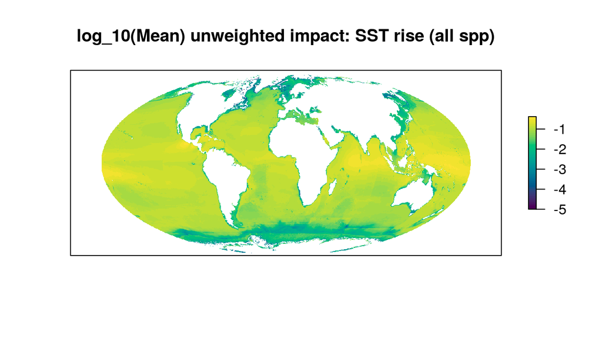

```r
mean_rast_unwt <- raster(impact_f_mean)
sdev_rast_unwt <- raster(impact_f_sdev)
cv_rast_unwt <- sdev_rast_unwt / mean_rast_unwt

map_cols <- hcl.colors(n = 50)

plot(log10(mean_rast_unwt), col = map_cols,
     main = 'log_10(Mean) unweighted impact: SST rise (all spp)',
     legend = TRUE, axes = FALSE)
```

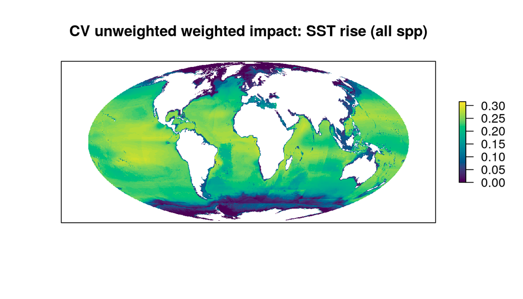

```r
plot(sdev_rast_unwt, col = map_cols,
     main = 'CV unweighted weighted impact: SST rise (all spp)',
     legend = TRUE, axes = FALSE)
```

## 3.3 Impacts by unweighted mean vulnerability, FE species only

### 3.3.1 Calculate mean thermal impacts per taxon

Loop over each taxon; pull all max temp stressor files for that taxon. For each species in the taxon, multiply thermal stressor map by the spp vulnerability to identify impact map for that species. Summarize across the entire taxon to mean, sd, and nspp.

```r
spp_fe <- read_csv(here('_output/func_entities/fe_species.csv'), show_col_types = FALSE)

spp_for_vuln_fe_only <- spp_for_vuln_calc %>%
  inner_join(spp_fe, by = 'species')

taxa <- spp_for_vuln_fe_only$taxon %>% unique() %>% sort()

out_stem_fe <- here_anx('impact_maps_by_taxon/impacts_tx_sst_rise',
                        'imp_unweighted_sst_rise_fe_only',
                        'imp_unweighted_sst_rise_fe_%s_%s.tif')
### zxcv <- list.files(dirname(out_stem_fe), full.names = TRUE)
### unlink(zxcv)
for(t in taxa) {
  ### t <- taxa[10]
  tx_vuln_df <- spp_for_vuln_fe_only %>%
    filter(taxon == t) %>%
    select(species, score) %>%
    distinct()

  outf_mean <- sprintf(out_stem_fe, t, 'mean')
  outf_sdev <- sprintf(out_stem_fe, t, 'sdev')
  outf_nspp <- sprintf(out_stem_fe, t, 'nspp')
  if(all(file.exists(outf_mean, outf_sdev, outf_nspp))) {
    message('Rasters exist for taxon ', t, ' for sst rise stressor... skipping!')
    next()
  }
  ### read in all sst thermal stressor maps for this taxon -
  tx_mapfiles <- mapfile_df %>%
    filter(species %in% tx_vuln_df$species) %>%
    distinct()

  message('Loading thermal stress maps for taxon ', t, '...')
  tx_maps_list <- parallel::mclapply(
                    tx_mapfiles$map_f,
                    mc.cores = 40,
                    FUN = function(f) {
                      if(file.exists(f)) {
                        df <- data.table::fread(f)
                        return(df)
                      } else {
                        return(data.frame(cell_id = -1,
                                          therm_prs = NA))
                      }
                    })
  if(check_tryerror(tx_maps_list)) {
    message('Something went wrong with loading maps for taxon ', t, '... skipping for now!')
    next()
  }
  message('Binding thermal stress maps for taxon ', t, ' FE species...')
  tx_maps <- tx_maps_list %>%
    setNames(tx_mapfiles$species) %>%
    data.table::rbindlist(idcol = 'species')

  message('Taxon ', t, ' thermal stressor dataframe: ', nrow(tx_maps),
          ' cell observations for ', n_distinct(tx_mapfiles$species),
          ' FE species...')
  if(any(tx_maps$cell_id == -1)) {
    n_na <- tx_maps %>%
      filter(cell_id == -1)
    message('NOTE: ', nrow(n_na), ' instances of missing thermal pressure maps detected!')
  }

  message('Processing mean/sd vulnerability by FE species in taxon ', t, ' to thermal stressor...')

  ### because failures might occur with summarizing a huge dataset,
  ### let's break this into chunks by cell_id - there are 6.6e+06 cells total
  chunk_size <- 500000
  n_chunks <- ceiling(ncell(raster::raster(here('_spatial/ocean_area_mol.tif'))) / chunk_size)
  n_cores <- max(1, floor(n_chunks / ceiling(nrow(tx_maps)/3e7)))
  # system.time({
  result_list <- parallel::mclapply(1:n_chunks, mc.cores = n_cores,
                 FUN = function(n) { ### n <- 3
                   cell_id_min <- as.integer((n - 1) * chunk_size + 1)
                   cell_id_max <- as.integer(n * chunk_size)
                   message('Summarizing thermal stressor on taxon ', t,
                           ': cells ', cell_id_min, ' - ', cell_id_max, '...')

                   chunk_sum <- tx_maps %>%
                     filter(between(cell_id, cell_id_min, cell_id_max)) %>%
                     oharac::dt_join(tx_vuln_df, by = 'species', type = 'inner') %>%
                     mutate(impact = score * therm_prs) %>%
                     group_by(cell_id) %>%
                     summarize(impact_mean = mean(impact) %>% round(5),
                               impact_sd   = sd(impact) %>% round(5),
                               n_spp       = n_distinct(species),
                               .groups = 'drop')
                   })

  if(check_tryerror(result_list)) {
    message('Something went wrong with calculations for taxon ', t, '... skipping for now!')
    next()
  }

  message('Binding results for taxon ', t, '...')
  result_df <- result_list %>%
    data.table::rbindlist() %>%
    filter(!is.na(cell_id))

  message('Creating and saving rasters for taxon ', t, '...')
  rast_mean <- map_to_mol(result_df, which = 'impact_mean')
  rast_sd   <- map_to_mol(result_df, which = 'impact_sd')
  rast_nspp <- map_to_mol(result_df, which = 'n_spp')

  writeRaster(rast_mean, outf_mean, overwrite = TRUE)
  writeRaster(rast_sd,   outf_sdev, overwrite = TRUE)
  writeRaster(rast_nspp, outf_nspp, overwrite = TRUE)
}
```

### 3.3.2 Summarize mean thermal impacts across all taxa

Combine taxon-level maps using nspp-weighted mean and pooled variance. Pooled var functions written and tested for script 2a.

```r
fe_tx_sst_map_df <- data.frame(f = list.files(dirname(out_stem_fe), full.names = TRUE)) %>%
  mutate(t = str_extract(basename(f), paste0(taxa, collapse = '|')),
         p = str_extract(basename(f), '_mean|_sdev|_nspp') %>% str_remove('_'))

impact_map_stem_fe <- here('_output/impact_maps/impact_maps_unweighted_fe_only',
                        'impact_unweighted_fe_only_sst_rise_%s.tif')
  ### %s is parameter (mean, sd, nspp)

### check if total stressor maps are complete
impact_f_mean <- sprintf(impact_map_stem_fe, 'mean')
impact_f_sdev <- sprintf(impact_map_stem_fe, 'sdev')

if(any(!file.exists(impact_f_mean, impact_f_mean))) {
  ### Combine mean, sdev, and nspp maps by taxon into one big dataframe
  message('Processing mean, sd, nspp maps across FE species for sst rise stressor...')
  big_df <- combine_taxa_maps(fe_tx_sst_map_df)
}

### Process mean raster across taxa
if(!file.exists(impact_f_mean)) {
  message('... summarizing mean vulnerability map across FE taxa...')
  ptm <- proc.time()

  all_spp_mean <- process_mean_rasts(big_df)
  rast_mean <- map_to_mol(all_spp_mean, which = 'vuln_mean')

  message('... elapsed: ', (proc.time() - ptm)[3], ' seconds.  ',
          'Writing out mean raster: \n  ',
          str_replace(impact_f_mean, '/home/ohara/github/', 'GitHub:'))

  writeRaster(rast_mean, impact_f_mean, overwrite = TRUE)
}

### Process standard deviation raster across taxa using pooled var
if(!file.exists(impact_f_sdev)) {
  message('... summarizing standard deviation vulnerability map across FE taxa...')
  ### break this into smaller chunks and parallelize over those?
  ptm <- proc.time()

  all_spp_sdev <- process_sdev_rasts(big_df)
  rast_sdev <- map_to_mol(all_spp_sdev, which = 'vuln_sdev')

  message('... elapsed: ', (proc.time() - ptm)[3], ' seconds.  ',
          'Writing out std dev raster: \n  ',
          str_replace(impact_f_sdev, '/home/ohara/github/', 'GitHub:'))

  writeRaster(rast_sdev, impact_f_sdev, overwrite = TRUE)
}
```

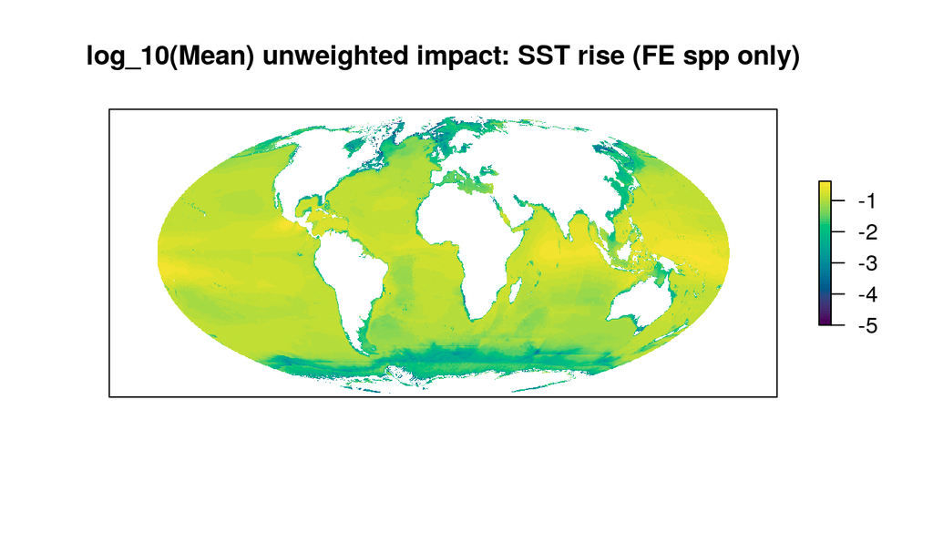

```r
mean_rast_unwt <- raster(impact_f_mean)
sdev_rast_unwt <- raster(impact_f_sdev)
cv_rast_unwt <- sdev_rast_unwt / mean_rast_unwt

map_cols <- hcl.colors(n = 50)

plot(log10(mean_rast_unwt), col = map_cols,
     main = 'log_10(Mean) unweighted impact: SST rise (FE spp only)',
     legend = TRUE, axes = FALSE)
```

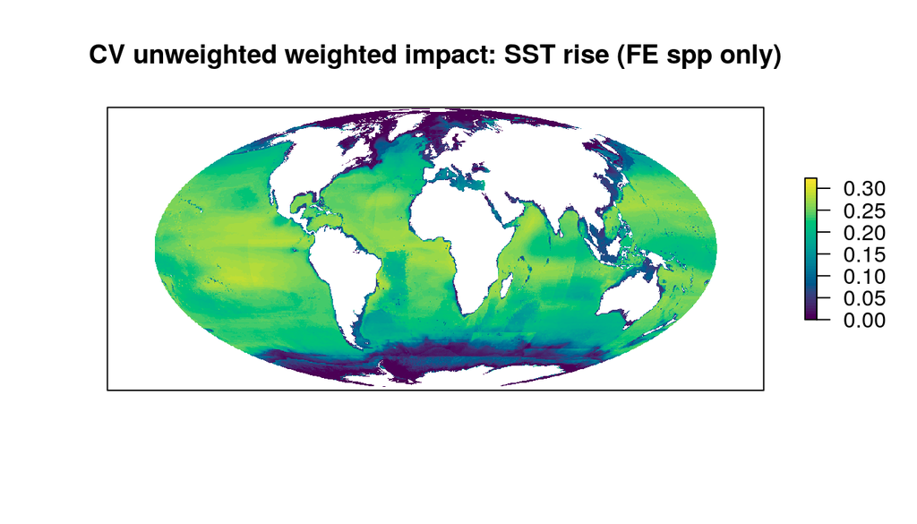

```r
plot(sdev_rast_unwt, col = map_cols,
     main = 'CV unweighted weighted impact: SST rise (FE spp only)',
     legend = TRUE, axes = FALSE)
```

## 3.4 Impacts by FV-weighted mean vulnerability

Here we will rely on similar code to that used in script 3a_map_vulnerability_FV_weighted.Rmd.

### 3.4.1 Tidy the loop

Because this is a complex process, let’s tidy the big `for` loop by breaking out key code as functions.

- `read_truncated_rangemap`: read in all range maps, truncating each one to just those cells in the current chunk.
- `calc_fv`: Calculate the functional vulnerability for a given functional entity based on the number of spp present.
- `calc_spp_cell_fv`: For each cell, identify all FEs and calculate the FV of each. Because grouping by large numbers of groups (e.g, 100000 cells and multiple FEs), for crash-avoidance, this is parallelized.
- `bind_maps_list`: for a list of truncated species maps, clean out NULL results and bind rows, keeping cell ID and species name.
- `calc_chunk_str_sum`: for a dataframe of truncated species maps

```r
read_truncated_temp_str_map <- function(f, chunk_start, chunk_end) {
  if(file.exists(f)) {
    df <- data.table::fread(f) %>%
      filter(between(cell_id, chunk_start, chunk_end)) %>%
      mutate(map_f = f)
  } else {
    df <- data.frame()
  }
  if(nrow(df) == 0) return(NULL) else return(df)
}

bind_maps_list <- function(chunk_maps_list, spp_for_vuln_fe_only) {
  ### NOTE: for some reason, the bind_rows() in here sometimes causes
  ### unrecoverable errors when knitting, but seems OK when running chunks
  ### individually... try subbing with data.table::rbindlist
  chunk_maps_raw <- chunk_maps_list %>%
    ### drop NULL instances (no spp cells - helps keep things from crashing)
    purrr::compact() %>%
    data.table::rbindlist()

  if(nrow(chunk_maps_raw) > 0) {
    ### if no spp-cell data for this chunk, skip bind and return 0-length df
    chunk_maps_raw <- chunk_maps_raw %>%
      oharac::dt_join(spp_for_vuln_fe_only, by = 'map_f', type = 'left') %>%
      select(-map_f, -src) %>%
      distinct()
  }
  return(chunk_maps_raw)
}

calc_chunk_str_sum <- function(chunk_maps, spp_for_vuln_fe_only) {
  chunk_spp_vuln <- spp_for_vuln_fe_only %>%
    filter(species %in% chunk_maps$species) %>%
    select(species, score) %>%
    distinct()

  cell_id_df <- data.frame(cell_id = chunk_maps$cell_id %>% unique()) %>%
    mutate(cell_gp = rep(1:100, length.out = n()))
  cell_gps <- cell_id_df$cell_gp %>% unique()

  chunk_spp_str_vuln <- chunk_maps %>%
    oharac::dt_join(chunk_spp_vuln, by = 'species', type = 'inner')

  ### parallelize for speed! balance vectorization with parallel to reduce crashing...
  chunk_impact_list <- parallel::mclapply(cell_gps, mc.cores = 25,
          FUN = function(gp) { ### gp <- 41
            cell_ids <- cell_id_df %>%
              filter(cell_gp == gp) %>%
              .$cell_id
            df <- chunk_spp_str_vuln %>%
              filter(cell_id %in% cell_ids) %>%
              mutate(impact = score * therm_prs) %>%
              group_by(cell_id, fe_id) %>%
              summarize(impact_mean = mean(impact), # %>% round(5),
                        impact_sd   = sd(impact), # %>% round(5),
                        n_spp       = n_distinct(species),
                        ### super-tiny fv (~ 1e-20) result in Inf var
                        fv = first(fv) %>% round(10),
                        .groups = 'drop') %>%
              group_by(cell_id) %>%
              summarize(n_spp = sum(n_spp),
                        fv_wt_mean_impact = Hmisc::wtd.mean(impact_mean, weights = fv),
                        fv_wt_sd_impact   = sqrt(Hmisc::wtd.var(impact_mean, weights = fv)))
          })
  chunk_impact_sum_df <- data.table::rbindlist(chunk_impact_list)
  return(chunk_impact_sum_df)
}

calc_fv <- function(n_spp) {
  k <- n_spp - 1
  fv <- 0.5^k
}

calc_spp_cell_fv <- function(chunk_maps_raw, spp_fe) {
  ### parallelize this mf to keep group_by from crashing everything - but not
  ### for every cell individually!  Set up 1000 different cell groups across
  ### the 100k(ish) cells - divide work between dplyr and parallel...
  cell_id_df <- data.frame(cell_id = chunk_maps_raw$cell_id %>% unique()) %>%
    mutate(cell_gp = rep(1:100, length.out = n()))
  cell_gps <- cell_id_df$cell_gp %>% unique()

  fe_df <- chunk_maps_raw %>%
    left_join(spp_fe %>% select(species, fe_id), by = 'species')
  fv_list <- parallel::mclapply(cell_gps, mc.cores = 25,
                                FUN = function(gp) {
                                  ### gp <- 52
                                  cell_ids <- cell_id_df %>%
                                    filter(cell_gp == gp) %>%
                                    .$cell_id
                                  x <- fe_df %>%
                                    filter(cell_id %in% cell_ids) %>%
                                    group_by(cell_id) %>%
                                    mutate(n_spp = n_distinct(species),
                                           n_fes = n_distinct(fe_id)) %>%
                                    group_by(cell_id, fe_id) %>%
                                    mutate(n_spp_fe = n_distinct(species),
                                           fv = calc_fv(n_distinct(species))) %>%
                                    ungroup()
                                  return(x)
                                })
  fv_df <- data.table::rbindlist(fv_list)
  return(fv_df)
}
```

```r
n_cells <- ncell(raster(here('_spatial/ocean_area_mol.tif')))
chunk_size <- 100000
n_chunks <- ceiling(n_cells / chunk_size)

tmp_stem_fv <- here_anx('impact_maps_by_taxon/impacts_tx_sst_rise',
                        'imp_fv_weighted_sst_rise',
                        'impact_summary_chunk_%s_to_%s_sst_rise.csv')
### zxcv <- list.files(dirname(tmp_stem_fv), full.names = TRUE)
### unlink(zxcv)

mapfile_fe_df <- mapfile_df %>%
  filter(species %in% spp_for_vuln_fe_only$species) %>%
  distinct()

for(chunk_i in 1:n_chunks) {
  ### chunk_i <- 1
  ### chunk_i <- 30

  ### Set up chunk start and end and filenames, check if they
  ### already exist for this chunk...
  chunk_start <- (chunk_i - 1) * chunk_size + 1
  chunk_end   <- as.integer(chunk_i * chunk_size)
  chunk_text <- sprintf('chunk %s of %s (cells %s to %s)',
                        chunk_i, n_chunks, chunk_start, chunk_end)

  ### check if all chunk-stressor maps are complete
  tmp_sst_rise_fv <- sprintf(tmp_stem_fv, chunk_start, chunk_end)
  if(file.exists(tmp_sst_rise_fv)) {
    message('SST rise stressor summary exists for ', chunk_text, '... skipping!')
    next()
  }

  ### Some chunk maps remain, so continue:
  ### Load species thermal pressure maps for this chunk, then clean and bind:
  message('Loading ', nrow(mapfile_fe_df), ' rangemaps cropped for ', chunk_text,  '...')

  chunk_maps_list <- parallel::mclapply(mapfile_fe_df$map_f, mc.cores = 30,
                                        ### f <- mapfile_fe_df$map_f[1]
                                        FUN = read_truncated_temp_str_map,
                                        chunk_start = chunk_start, chunk_end = chunk_end)

  chunk_maps_raw <- bind_maps_list(chunk_maps_list, mapfile_fe_df)

  ### if result includes no cells, write out empty chunk files
  if(nrow(chunk_maps_raw) == 0) {
    message('No species X cells found for ', chunk_text, '... skipping to next chunk!')
    write_csv(data.frame(), tmp_sst_rise_fv)
    next()
  }

  ### OK, now we have species and cells for this chunk.  Calculate functional vulnerability!
  message('... Calculating functional vulnerability metrics for ', nrow(chunk_maps_raw),
          ' spp-cells in ', chunk_text, '...')
  chunk_maps <- chunk_maps_raw %>%
    calc_spp_cell_fv(spp_fe)

  message('... In ', chunk_text,  ' rangemap dataframe: \n    ', nrow(chunk_maps),
          ' cell observations for ', n_distinct(chunk_maps$species), ' species across ',
          n_distinct(chunk_maps$fe_id), ' functional entities...')

  message('... Processing mean/sd vuln in ', chunk_text, ' to stressor: sst rise...')
  chunk_str_sum <- calc_chunk_str_sum(chunk_maps, spp_for_vuln_fe_only)

  write_csv(chunk_str_sum, tmp_sst_rise_fv)
}
```

### 3.4.2 Aggregate chunk vulnerability maps to global map

For each stressor, pull in all chunk dataframes, assemble into dataframe, and save out as rasters.

```r
chunk_files <- list.files(dirname(tmp_stem_fv),
                          pattern = 'impact_summary_chunk', full.names = TRUE)

rast_fv_out_stem <- here('_output/impact_maps/impact_maps_fv_weighted',
                         'impact_fv_weighted_sst_rise_%s.tif')

rast_mean_impact_fv_f <- sprintf(rast_fv_out_stem, 'mean')
rast_sdev_impact_fv_f <- sprintf(rast_fv_out_stem, 'sdev')

if(any(!file.exists(rast_mean_impact_fv_f, rast_sdev_impact_fv_f))) {
  message('Gathering impact chunk maps for sst rise...')

  impact_map_df <- parallel::mclapply(chunk_files, mc.cores = 33,
                                      FUN = data.table::fread) %>%
    bind_rows() %>%
    mutate(fv_wt_mean_impact = round(fv_wt_mean_impact, 5),
           fv_wt_sd_impact   = round(fv_wt_sd_impact,   5))

  message('Converting impact maps to rasters for sst rise...')
  mean_rast_fvwt <- map_to_mol(impact_map_df,
                               by = 'cell_id', which = 'fv_wt_mean_impact')
  sdev_rast_fvwt <- map_to_mol(impact_map_df, by = 'cell_id', which = 'fv_wt_sd_impact')

  message('Writing impact rasters for sst rise...')
  writeRaster(mean_rast_fvwt, rast_mean_impact_fv_f, overwrite = TRUE)
  writeRaster(sdev_rast_fvwt, rast_sdev_impact_fv_f, overwrite = TRUE)
}
```

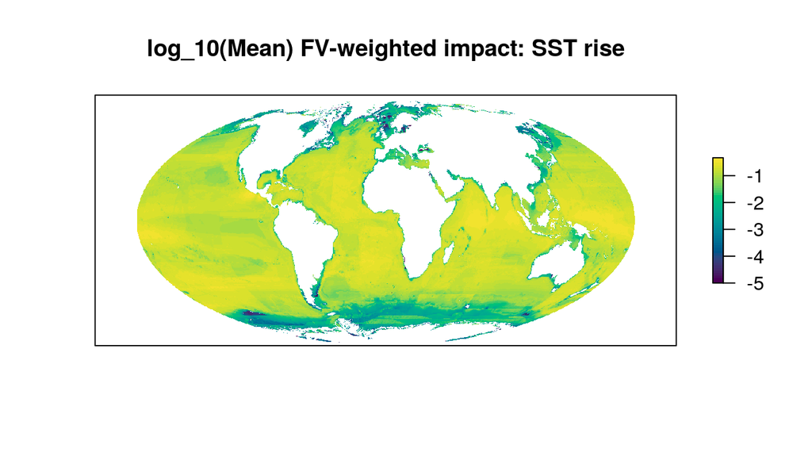

```r
mean_rast_fvwt <- raster(rast_mean_impact_fv_f)
sdev_rast_fvwt <- raster(rast_sdev_impact_fv_f)
cv_rast_fvwt <- sdev_rast_fvwt / mean_rast_fvwt

map_cols <- hcl.colors(n = 50)

plot(log10(mean_rast_fvwt), col = map_cols,
     main = 'log_10(Mean) FV-weighted impact: SST rise',
     legend = TRUE, axes = FALSE)
```

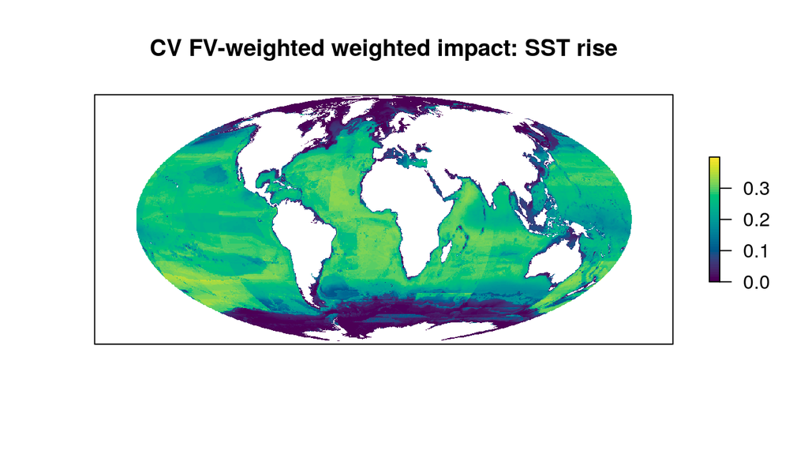

```r
plot(sdev_rast_fvwt, col = map_cols,
     main = 'CV FV-weighted weighted impact: SST rise',
     legend = TRUE, axes = FALSE)
```

## 3.5 Difference maps

Loop over several focal stressors. For each stressor, read in the maps of unweighted mean impact $\bar x$ and fv-weighted mean impact $\bar x_{FV}$. Calculate difference as proportional difference in FV-weighted mean relative to unweighted mean impact:
$$diff = (\bar x_{FV} - \bar x) / \bar x$$

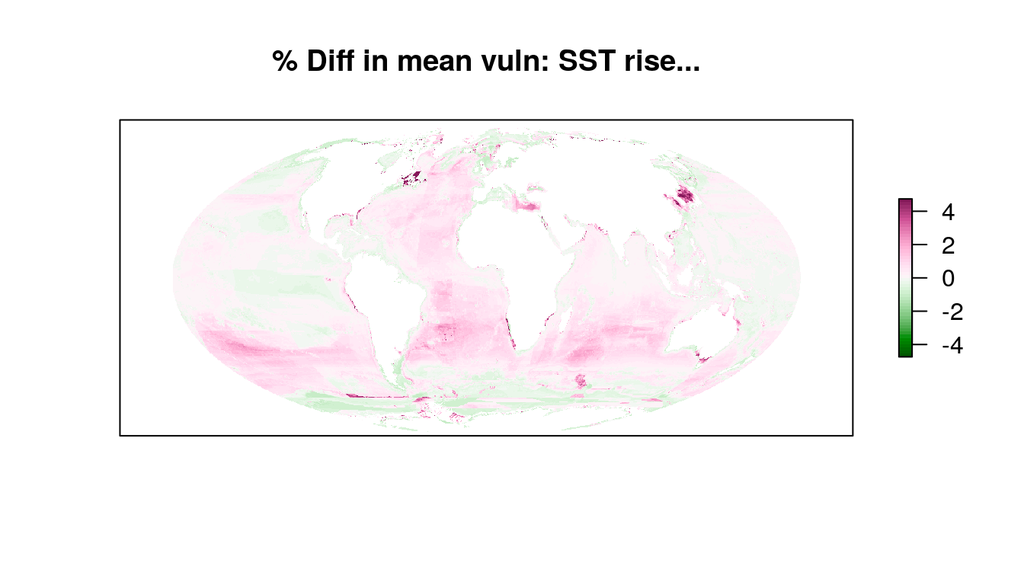

```r
squish_rast <- function(r, qtile = .999) {
  r_vals <- values(r); r_vals <- r_vals[!is.na(r_vals)]
  r_zlim <- max(abs(quantile(r_vals, 1 - qtile)), abs(quantile(r_vals, qtile)))
  values(r)[values(r) > r_zlim] <- r_zlim
  values(r)[values(r) < -r_zlim] <- -r_zlim

  return(list(r = r, zlim = r_zlim))
}

### Set up rasters; trim extreme values
mean_diff_rast <- (mean_rast_fvwt - mean_rast_unwt) / mean_rast_unwt
mean_diff_squished <- squish_rast(mean_diff_rast, qtile = .999)
# cv_diff_rast <- (cv_rast_fvwt - cv_rast_unwt) / cv_rast_unwt
# cv_r_sq <- squish_rast(cv_diff_rast, qtile = .999)

m_d_mask_0.10 <- m_d_mask_0.25 <- mean_diff_squished$r
values(m_d_mask_0.10)[values(mean_rast_unwt) < .10 & values(mean_rast_fvwt) < .10] <- NA
values(m_d_mask_0.25)[values(mean_rast_unwt) < .25 & values(mean_rast_fvwt) < .25] <- NA

message('Plotting difference maps for SST rise...')

### Set up plot for diverging palette, and symmetric z limits around zero
map_cols <- hcl.colors(palette = 'Red-Green', n = 50, rev = TRUE)

plot(mean_diff_squished$r, col = map_cols,
     main = '% Diff in mean vuln: SST rise...',
     zlim = c(-mean_diff_squished$zlim, mean_diff_squished$zlim),
     legend = TRUE, axes = FALSE)
```

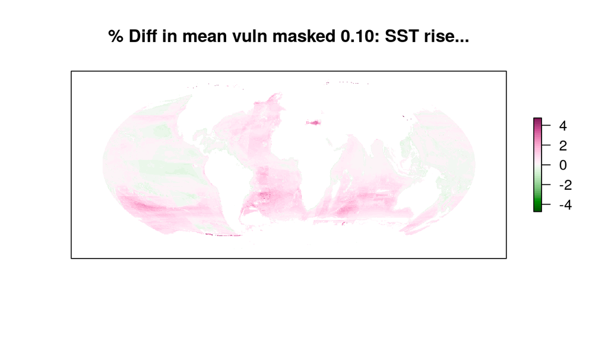

```r
plot(m_d_mask_0.10, col = map_cols,
     main = '% Diff in mean vuln masked 0.10: SST rise...',
     zlim = c(-mean_diff_squished$zlim, mean_diff_squished$zlim),
     legend = TRUE, axes = FALSE)
```

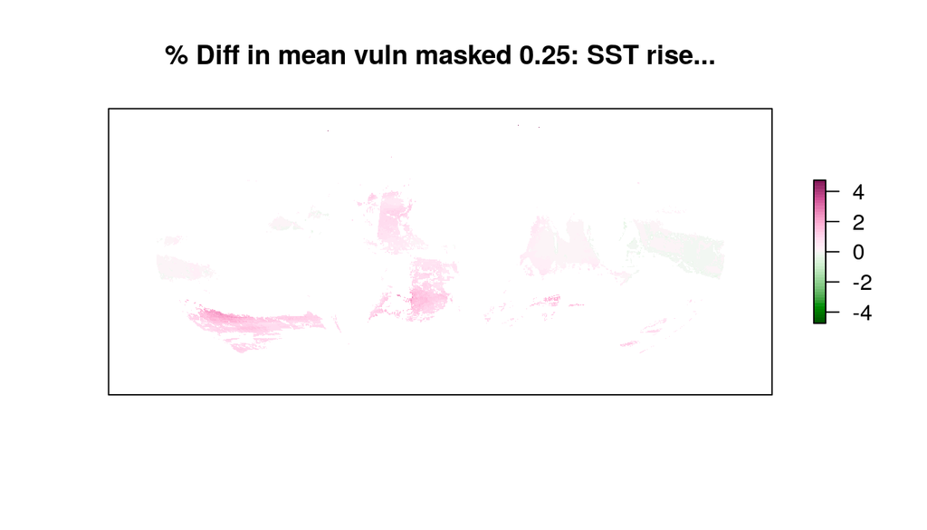

```r
plot(m_d_mask_0.25, col = map_cols,
     main = '% Diff in mean vuln masked 0.25: SST rise...',
     zlim = c(-mean_diff_squished$zlim, mean_diff_squished$zlim),
     legend = TRUE, axes = FALSE)
```